# ‘SangerAlignment’ Report

Author: Kuan-Hao Chao (u7022787@anu.edu.au)

Last update: 02 February, 2020

SangerAlignment Level

SangerContig Level

SangerRead Level

# 1 Basic Information:

- **Output Directory :** */var/folders/33/7v38jdjd2874jcxb6l71m00h0000gn/T//RtmpqDuQ5Y/SangerAlignment*
- **Input Parent Directory :** */Users/chaokuan-hao/Library/R/3.6/library/sangeranalyseR*
- **Trimming Method :** *M1*
- **Forward Reads Suffix Regex :** *_[0-9]*_F.ab1*
- **Reverse Reads Suffic Regex :** *_[0-9]*_R.ab1*
- **Minimum Fraction Call (SA) :** *0.5*
- **Maximum Fraction Lost (SA) :** *0.5*

# 2 Contigs Consensus

### Primary Sequence

[interactive chart not shown]

# 3 Contigs Alignment

[output not shown]

# 4 Contigs Tree

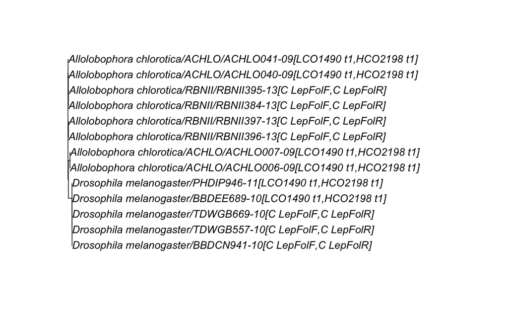

# Contigs Reports

- Go to Contig: “ACHLO006-09[LCO1490_t1,HCO2198_t1]” Report
- Go to Contig: “ACHLO007-09[LCO1490_t1,HCO2198_t1]” Report
- Go to Contig: “ACHLO040-09[LCO1490_t1,HCO2198_t1]” Report
- Go to Contig: “ACHLO041-09[LCO1490_t1,HCO2198_t1]” Report
- Go to Contig: “RBNII384-13[C_LepFolF,C_LepFolR]” Report
- Go to Contig: “RBNII395-13[C_LepFolF,C_LepFolR]” Report
- Go to Contig: “RBNII396-13[C_LepFolF,C_LepFolR]” Report
- Go to Contig: “RBNII397-13[C_LepFolF,C_LepFolR]” Report
- Go to Contig: “BBDCN941-10[C_LepFolF,C_LepFolR]” Report
- Go to Contig: “BBDEE689-10[LCO1490_t1,HCO2198_t1]” Report
- Go to Contig: “PHDIP946-11[LCO1490_t1,HCO2198_t1]” Report
- Go to Contig: “TDWGB557-10[C_LepFolF,C_LepFolR]” Report
- Go to Contig: “TDWGB669-10[C_LepFolF,C_LepFolR]” Report